# Producer Theory

# What Shifts the Budget Constraint?

## Change in Income 📈

**What happens if our tourist’s budget increases from €100 to €150?**

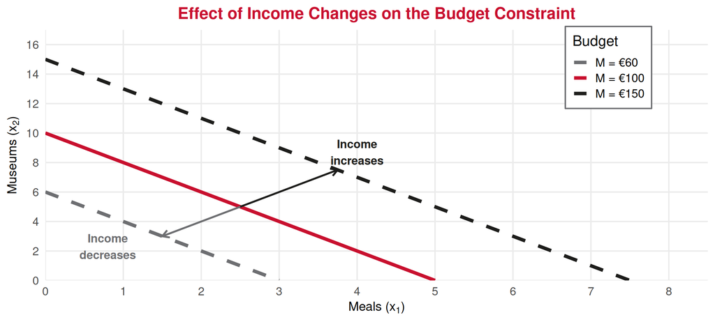

👉 Income change: **parallel shift** (slope unchanged at $-p_1/p_2$)

## Change in Price of Good 1 🏷️

**What if meal prices drop from €20 to €10?**

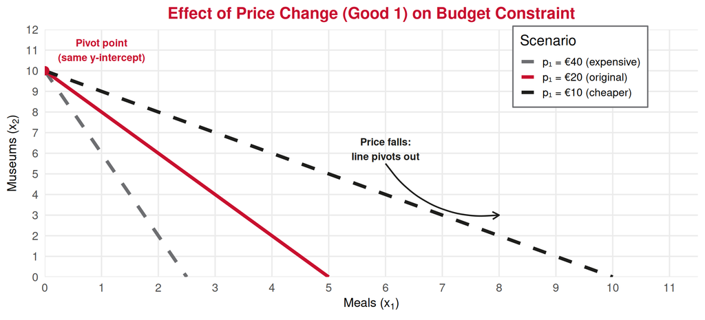

👉 Price change of **one** good: **pivot** around the other intercept (slope changes!)

## Summary: What Shifts What? 📝

| Change | Effect on Budget Line | Slope | Intercepts |
| --- | --- | --- | --- |
| ⬆️ Income ($M$) | Parallel shift **outward** | Same | Both increase |
| ⬇️ Income ($M$) | Parallel shift **inward** | Same | Both decrease |
| ⬇️ Price $p_1$ | Pivot **outward** on $x_1$ axis | Flatter | $x_1$-intercept increases |
| ⬆️ Price $p_1$ | Pivot **inward** on $x_1$ axis | Steeper | $x_1$-intercept decreases |
| ⬇️ Price $p_2$ | Pivot **outward** on $x_2$ axis | Steeper | $x_2$-intercept increases |
| ⬆️ Price $p_2$ | Pivot **inward** on $x_2$ axis | Flatter | $x_2$-intercept decreases |

💡 **Key insight**: The slope $-p_1/p_2$ is the **relative price** — what the *market* says one good costs in terms of the other.

## The Slope as Opportunity Cost ⚖️

The slope of the budget constraint has a direct economic interpretation:

$$\text{Slope} = -\frac{p_1}{p_2}$$

This tells us the **market’s exchange rate** between the two goods.

**Our example**: $-20/10 = -2$

For 1 extra meal, you **must** give up 2 museum visits.

This is **not** a preference — it is a constraint imposed by prices!

👉 Compare with the **PPF slope** from Lecture 4

- PPF slope: society’s opportunity cost (technology)
- Budget line slope: individual’s opportunity cost (prices)

**Both represent trade-offs, at different scales!**

# Tourism Applications

## Application: Exchange Rates & Tourist Budgets 💶

**How exchange rates shift a tourist’s budget constraint**

A British tourist visits Portugal with **£500** to spend on:

- 🏨 **Accommodation**: €80/night
- 🍴 **Dining**: €20/meal

**Scenario A**: £1 = €1.15

Budget in €: £500 × 1.15 = **€575**

- Max nights: 575/80 ≈ **7.2**
- Max meals: 575/20 ≈ **28.8**

**Scenario B**: £1 = €1.30

Budget in €: £500 × 1.30 = **€650**

- Max nights: 650/80 ≈ **8.1**
- Max meals: 650/20 ≈ **32.5**

👉 A stronger pound = **parallel outward shift** of the budget constraint in euro terms. The tourist can afford more of *everything*!

## Numerical Example: Step by Step 🧮

**Problem**: A tourist has **€200** to spend. Surfing lessons cost **€40** each. Fado show tickets cost **€25** each.

**Step 1**: Write the budget constraint

$$40 x_1 + 25 x_2 = 200$$

**Step 2**: Find intercepts

- If $x_1 = 0$: $x_2 = 200/25 = 8$ fado shows
- If $x_2 = 0$: $x_1 = 200/40 = 5$ surf lessons

**Step 3**: Find the slope

$$\text{Slope} = -\frac{p_1}{p_2} = -\frac{40}{25} = -1.6$$

👉 1 extra surf lesson costs 1.6 fado shows

**Step 4**: Check an interior bundle — (2 surf, 4 fado): $40(2) + 25(4) = 80 + 100 = 180 \leq 200$ ✅ (inside budget set, €20 unspent)

## General Formulas: Cheat Sheet 📋

**Budget Constraint Formulas**

**Equation**: $p_1 x_1 + p_2 x_2 = M$

**Solved for** $x_2$: $\displaystyle x_2 = \frac{M}{p_2} - \frac{p_1}{p_2} x_1$

**Vertical intercept** ($x_1 = 0$): $\displaystyle \frac{M}{p_2}$

**Horizontal intercept** ($x_2 = 0$): $\displaystyle \frac{M}{p_1}$

**Slope**: $\displaystyle -\frac{p_1}{p_2}$ (the relative price of good 1 in terms of good 2)

## Summary: Today’s Key Takeaways

**Today’s Lecture Integration**:

1. **Income** ($M$) and **prices** ($p_1, p_2$) define the consumer’s constraint
2. **Budget line**: $p_1 x_1 + p_2 x_2 = M$ — all bundles spending exactly all income
3. **Budget set**: $p_1 x_1 + p_2 x_2 \leq M$ — all affordable bundles
4. **Slope** = $-p_1/p_2$ = market rate of exchange between goods
5. Income changes ➡️ **parallel shift**
6. Price changes ➡️ **pivot** (rotation)

**Connection to previous lectures**: The budget line is the *individual-level analog* of the PPF — both show feasible combinations and trade-offs.

**Next**: Lecture 6 — Consumer **Preferences** and axioms of rationality. We’ll ask: *among all affordable bundles, which one does the consumer actually want?*

## Exercises

**Application Time!** ✏️

Budget constraint calculations and graphical analysis.

## Exercise 1: Multiple Choice

**Question**: A consumer has income $M = 120$, with $p_1 = 15$ and $p_2 = 10$. The slope of the budget constraint is:

A. $-10/15$  
B. $-15/10$  
C. $-120/15$  
D. $-120/10$

**Answer: B**

The slope of the budget line is always $-p_1/p_2 = -15/10 = -1.5$. This means for each additional unit of good 1, the consumer must give up 1.5 units of good 2. Note: income affects the *position* of the line, not its slope.

## Exercise 2: Multiple Choice

**Question**: If the price of good 2 **doubles** while income and $p_1$ stay the same, the budget line:

A. Shifts outward in parallel  
B. Pivots inward around the $x_1$-intercept  
C. Pivots outward around the $x_2$-intercept  
D. Pivots inward around the $x_2$-intercept

**Answer: B**

When $p_2$ doubles: the $x_2$-intercept ($M/p_2$) **halves** (moves down), while the $x_1$-intercept ($M/p_1$) **stays the same**. So the line **pivots inward around the $x_1$-intercept**. The consumer can buy less of good 2 but the same maximum of good 1. The slope $-p_1/p_2$ becomes smaller in absolute value (the line becomes flatter).

## Exercise 3: Open Question

**Scenario**: A Portuguese tourism student plans a weekend trip. She has a budget of **€150**. She wants to split spending between:

- 🏄‍♀️ **Surf lessons**: €30 each ($x_1$)
- 🍷 **Wine tasting tours**: €25 each ($x_2$)

**Questions**:

1. Write the budget constraint equation and solve for $x_2$.
2. Calculate and interpret the slope. What is the opportunity cost of one surf lesson in terms of wine tastings?
3. Find both intercepts. Draw the budget constraint with $x_1$ on the horizontal axis.
4. Is the bundle (2 surf lessons, 3 wine tastings) affordable? Is it on the budget line?
5. Suppose the student receives a €50 gift card (total budget now €200). Draw the new budget line on the same graph. What changed and what stayed the same?
6. Now instead of the gift card, suppose surf lesson prices drop to €25 (budget stays at €150). Draw this new line. How does it differ from part (e)?

## Exercise 3: Solution — Parts a, b, c

**a)** Budget constraint: $30x_1 + 25x_2 = 150$

Solving for $x_2$: $x_2 = \frac{150}{25} - \frac{30}{25}x_1 = 6 - 1.2x_1$

**b)** Slope $= -p_1/p_2 = -30/25 = -1.2$

👉 Each surf lesson costs 1.2 wine tastings. The opportunity cost of 1 surf lesson is 1.2 wine tours foregone.

**c)** Intercepts:

- $x_1 = 0 \Rightarrow x_2 = 150/25 = 6$ wine tastings (vertical intercept)
- $x_2 = 0 \Rightarrow x_1 = 150/30 = 5$ surf lessons (horizontal intercept)

Graph: straight line from $(0, 6)$ to $(5, 0)$.

## Exercise 3: Solution — Parts d, e, f

**d)** Bundle (2, 3): $30(2) + 25(3) = 60 + 75 = 135 \leq 150$ ✅

**Affordable?** Yes! **On the budget line?** No — she spends only €135, leaving €15 unspent. The bundle is **inside** the budget set.

**e)** New budget €200: $30x_1 + 25x_2 = 200 \Rightarrow x_2 = 8 - 1.2x_1$

- New intercepts: $(0, 8)$ and $(6.67, 0)$
- **Parallel shift outward** — slope unchanged at $-1.2$

**f)** Price drop $p_1 = 25$, $M = 150$: $25x_1 + 25x_2 = 150 \Rightarrow x_2 = 6 - x_1$

- New intercepts: $(0, 6)$ and $(6, 0)$
- **Pivot outward** around vertical intercept — slope changes to $-1$

**Key difference**: (e) is a parallel shift (more of both goods equally); (f) is a pivot (relatively more surf lessons become affordable, wine tasting maximum unchanged).

## Next Lecture

**February 20, 2026**: Consumer Preferences & Axioms of Rationality

We answered: *What can the consumer afford?*

Next, we ask: *What does the consumer **want**?* 🤔

## Thank You!

**Questions?** 🙋

📧 paulo.fagandini@ext.universidadeeuropeia.pt

*Next class: Tomorrow, Friday, February 20, 2026*